# DATA 603: Assignment 3

*Deadline: Nov. 29th, 2019. Submit to Dropbox via D2L.*

# Logistic Regression

**Problem 1.** A study investigated characteristics associated with y= whether a cancer patient achieved remission (1=yes, 0=no). An important explanatory variable was a labeling index (LI=percentage of “labeled” cells) that measures proliferative activity of cells after a patient receives an injection of tritiated thymidine. Fit a logistic regression model in order to answer the following questions. The data is provided in **remission.scv** file.

1. Estimate the probabilities of a cancer patient achieved remission when LI=15 and LI=37. Comment on your results.

```r
mylogit <- glm(y ~LI, data = remission, family = "binomial")
summary(mylogit)
```

```
##
## Call:
## glm(formula = y ~ LI, family = "binomial", data = remission)
##
## Deviance Residuals:
##      Min        1Q    Median        3Q       Max
## -2.15450  -0.52277   0.09487   0.39040   2.42125
##
## Coefficients:
##             Estimate Std. Error z value Pr(>|z|)
## (Intercept) -7.01530    0.68349  -10.26   <2e-16 ***
## LI           0.31838    0.03061   10.40   <2e-16 ***
## ---
## Signif. codes:  0 '***' 0.001 '**' 0.01 '*' 0.05 '.' 0.1 ' ' 1
##
## (Dispersion parameter for binomial family taken to be 1)
##
##     Null deviance: 553.31  on 399  degrees of freedom
## Residual deviance: 266.84  on 398  degrees of freedom
## AIC: 270.84
##
## Number of Fisher Scoring iterations: 6
```

```r
probLi15=predict(mylogit,data.frame(LI=15),type="response")
probLi15
```

```
##          1
## 0.09624499
```

```r
probLi37=predict(mylogit,data.frame(LI=37),type="response")
probLi37
```

```
##         1
## 0.9915459
```

<!–

The first method can be done by subtituting values of coefficient estimates.

$Prob(y=1/LI=15)=\frac{\exp(-7.0153+0.3183\times 15)}{(1+\exp(-7.0153+0.3183\times 15))}= 0.0962$

$Prob(y=1/LI=37)=\frac{\exp(-7.0153+0.3183\times 37)}{(1+\exp(-7.0153+0.3183\times 37))}=0.9915$

The second method can be done using the R command *predict*.

–>

2. Interpret the effect of LI in terms of the odds.

<!–

When LI increases by 1 percentage of labeled cells, the estimated odds of remission multiply by $\exp(0.3183)= 1.3747$. i.e the odds of remission increases by 37.47%.

–>

3. Compute 95% confidence intervals for the logistic regression coefficient ($\hat{\beta}$) and its associated odds. Give an interpretation.

```r
confint(mylogit)
```

```
##                  2.5 %     97.5 %
## (Intercept) -8.4561952 -5.7656003
## LI           0.2626089  0.3831168
```

```r
exp(confint(mylogit))
```

```
##                    2.5 %      97.5 %
## (Intercept) 0.0002125794 0.003133514
## LI          1.3003180838 1.466849322
```

<!– When LI increases of 1 percentage labeled cells, the estimated odds of remission increases between 30.03% and 46.68%. –>

4. Use the Wald Z test and Likelihood ratio test to confirm that the LI predictor is associated with remission of cancer at alpha=0.05.

```r
mylogit2 <- glm(y ~1, data = remission, family = "binomial")
library(lmtest)
lrtest(mylogit2,mylogit)
```

|  | #Df | LogLik | Df | Chisq | Pr(>Chisq) |
| --- | --- | --- | --- | --- | --- |
| 1 | 1 | -276.6536 | NA | NA | NA |
| 2 | 2 | -133.4202 | 1 | 286.4666 | 2.927255e-64 |

|  | #Df <dbl> | LogLik <dbl> | Df <dbl> | Chisq <dbl> | Pr(>Chisq) <dbl> |
| --- | --- | --- | --- | --- | --- |
| 1 | 1 | -276.6536 | NA | NA | NA |
| 2 | 2 | -133.4202 | 1 | 286.4666 | 2.927255e-64 |

2 rows

<!– The Wald Z statistics is $Z=10.40$ with a p-value<2e-16. Moreover, using the likelihood ratio test, the chi-square statistics is 286.466 with p-value=2.92e-64. Hence, this confirms that LI is significantly associated with the remission response.

–>

**Problem 2.** The RMS Titanic was a British passenger liner that sank in the North Atlantic Ocean in the early morning hours of 15 April 1912, after it collided with an iceberg during its maiden voyage from Southampton to New York City. The RMS Titanic was the largest ship a float at the time it entered service and was the second of three Olympic-class ocean liners operated by the White Star Line. The Titanic was built by the Harland and Wolff shipyard in Belfast. Thomas Andrews, her architect, died in the disaster. The training-dataset with 891 examples is provided in **titanic.csv** file and the list of Variables with a short description is provided:

survival: Survival

PassengerId: Unique Id of a passenger.

pclass: Ticket class

sex: Sex

Age: Age in years

1. Test if the chances of survival of passengers in Titanic depends on those variables at $\alpha=0.05$

```r
mylogit <- glm(Survived ~factor(Pclass)+factor(Sex)+Age, data = titanic, family = "binomial")
mylogit2 <- glm(Survived ~1, data = titanic, family = "binomial")
anova(mylogit2,mylogit,test ='Chisq' )
```

|  | Resid. Df | Resid. Dev | Df | Deviance | Pr(>Chi) |
| --- | --- | --- | --- | --- | --- |
| 1 | 890 | 1186.6551 | NA | NA | NA |
| 2 | 886 | 826.3428 | 4 | 360.3124 | 1.040441e-76 |

|  | Resid. Df <dbl> | Resid. Dev <dbl> | Df <dbl> | Deviance <dbl> | Pr(>Chi) <dbl> |
| --- | --- | --- | --- | --- | --- |
| 1 | 890 | 1186.6551 | NA | NA | NA |
| 2 | 886 | 826.3428 | 4 | 360.3124 | 1.040441e-76 |

2 rows

```r
summary(mylogit)
```

```
##
## Call:
## glm(formula = Survived ~ factor(Pclass) + factor(Sex) + Age,
##     family = "binomial", data = titanic)
##
## Deviance Residuals:
##     Min       1Q   Median       3Q      Max
## -2.2351  -0.7181  -0.4394   0.6446   2.2226
##
## Coefficients:
##                  Estimate Std. Error z value Pr(>|z|)
## (Intercept)      2.168645   0.278194   7.795 6.42e-15 ***
## factor(Pclass)2 -0.844969   0.244814  -3.451 0.000558 ***
## factor(Pclass)3 -1.915201   0.214757  -8.918  < 2e-16 ***
## factor(Sex)male -2.646375   0.184335 -14.356  < 2e-16 ***
## Age              0.004504   0.006096   0.739 0.459929
## ---
## Signif. codes:  0 '***' 0.001 '**' 0.01 '*' 0.05 '.' 0.1 ' ' 1
##
## (Dispersion parameter for binomial family taken to be 1)
##
##     Null deviance: 1186.66  on 890  degrees of freedom
## Residual deviance:  826.34  on 886  degrees of freedom
## AIC: 836.34
##
## Number of Fisher Scoring iterations: 4
```

<!– *We are testing $H_0: \beta_{class2}=\beta_{class3}=\beta_{male}=\beta_{age}=0$ versus $H_a: \mbox{at least one } \beta_i$ is not zero. $i=male, class2,class3,age$.*

*From the output, using likelihood ratio test, we can conclude that the chances of survival of passengers in Titanic depend at least on one of those varaibles as p-value=1.040441e-76<0.05. Moreover, by looking at the individual Wald Z tests, we can conclude that the chances of survival of passengers in Titanic depends on PCclass and Sex as both p-values < 0.05.*

–>

2. From part a), use the likelihood ratio test to check whether the variable age should be in the full model.

```r
mylogit <- glm(Survived ~factor(Pclass)+factor(Sex)+Age, data = titanic, family = "binomial")
#part c) , part d) for AIC
mylogit3 <- glm(Survived ~factor(Pclass)+factor(Sex), data = titanic, family = "binomial")
summary(mylogit3)
```

```
##
## Call:
## glm(formula = Survived ~ factor(Pclass) + factor(Sex), family = "binomial",
##     data = titanic)
##
## Deviance Residuals:
##     Min       1Q   Median       3Q      Max
## -2.1877  -0.7312  -0.4476   0.6465   2.1681
##
## Coefficients:
##                 Estimate Std. Error z value Pr(>|z|)
## (Intercept)       2.2971     0.2190  10.490  < 2e-16 ***
## factor(Pclass)2  -0.8380     0.2447  -3.424 0.000618 ***
## factor(Pclass)3  -1.9055     0.2141  -8.898  < 2e-16 ***
## factor(Sex)male  -2.6419     0.1841 -14.351  < 2e-16 ***
## ---
## Signif. codes:  0 '***' 0.001 '**' 0.01 '*' 0.05 '.' 0.1 ' ' 1
##
## (Dispersion parameter for binomial family taken to be 1)
##
##     Null deviance: 1186.66  on 890  degrees of freedom
## Residual deviance:  826.89  on 887  degrees of freedom
## AIC: 834.89
##
## Number of Fisher Scoring iterations: 4
```

```r
anova(mylogit3,mylogit,test='Chisq')
```

|  | Resid. Df | Resid. Dev | Df | Deviance | Pr(>Chi) |
| --- | --- | --- | --- | --- | --- |
| 1 | 887 | 826.8884 | NA | NA | NA |
| 2 | 886 | 826.3428 | 1 | 0.5455971 | 0.4601223 |

|  | Resid. Df <dbl> | Resid. Dev <dbl> | Df <dbl> | Deviance <dbl> | Pr(>Chi) <dbl> |
| --- | --- | --- | --- | --- | --- |
| 1 | 887 | 826.8884 | NA | NA | NA |
| 2 | 886 | 826.3428 | 1 | 0.5455971 | 0.4601223 |

2 rows

```r
# Second option
library(lmtest)
lrtest(mylogit3,mylogit)
```

|  | #Df | LogLik | Df | Chisq | Pr(>Chisq) |
| --- | --- | --- | --- | --- | --- |
| 1 | 4 | -413.4442 | NA | NA | NA |
| 2 | 5 | -413.1714 | 1 | 0.5455971 | 0.4601223 |

|  | #Df <dbl> | LogLik <dbl> | Df <dbl> | Chisq <dbl> | Pr(>Chisq) <dbl> |
| --- | --- | --- | --- | --- | --- |
| 1 | 4 | -413.4442 | NA | NA | NA |
| 2 | 5 | -413.1714 | 1 | 0.5455971 | 0.4601223 |

2 rows

<!–

*$H_o$: $\beta_{AGE}=0$ versus $H_a$: $\beta_{AGE}\neq 0$*

*The output from both functions confirms that the effect of AGE variable is not significant to be in the model as p-value =0.461 > 0.05 so we fail to reject $H_o$.*

–>

3. Write the logit and logistic regression model for predicting the chances of survival of passengers in Titanic.

<!–

*The logit model is $\hat{logit}=\hat{\beta}_0+\hat{\beta}_1Pclass2+\hat{\beta}_2Pclass3+\hat{\beta}_3Sex$*.

$$\begin{aligned}
\hat{logit}=
\begin{cases}
2.2971−2.6419=-0.3448&\mbox{ if Male and Class 1}\\
2.2971−0.8380−2.6419=-1.1828&\mbox{ if Male and Class 2}\\
2.2971−1.9055−2.6419=-2.2503&\mbox{ if Male and Class 3}\\
2.2971&\mbox{ if Female and Class 1}\\
2.2971−0.8380=1.4591&\mbox{ if Female and Class 2}\\
2.2971−1.9055=0.3916&\mbox{ if Female and Class 3}\\
\end{cases}
\end{aligned}$$
*The logistic model is $Prob(Y=1|Sex, Pclass)=\frac{\exp(\hat{\beta}_0+\hat{\beta}_1Pclass2+\hat{\beta}_2Pclass3+\hat{\beta}_3Sex)}{1+\exp(\hat{\beta}_0+\hat{\beta}_1Pclass2+\hat{\beta}_2Pclass3+\hat{\beta}_3Sex)}$*
$$\begin{aligned}
\hat{\pi}=Prob(Y=1|Sex, Pclass)=
\begin{cases}
0.41533&\mbox{ if Male and Class 1}\\
0.2345&\mbox{ if Male and Class 2}\\
0.0953&\mbox{ if Male and Class 3}\\
0.9087&\mbox{ if Female and Class 1}\\
0.81139&\mbox{ if Female and Class 2}\\
0.5966&\mbox{ if Female and Class 3}\\
\end{cases}
\end{aligned}$$
–>

4. Interpret the effect of Class and Sex in terms of the odds ratio from the logistic regression model in part c)

```r
exp(coef(mylogit3))
```

```
##     (Intercept) factor(Pclass)2 factor(Pclass)3 factor(Sex)male
##      9.94552998      0.43259543      0.14874898      0.07122757
```

<!–

5. Report Deviance, AIC, ROC with AUC (the model fit) from the model in part c)

```r
summary(mylogit3)
```

```
##
## Call:
## glm(formula = Survived ~ factor(Pclass) + factor(Sex), family = "binomial",
##     data = titanic)
##
## Deviance Residuals:
##     Min       1Q   Median       3Q      Max
## -2.1877  -0.7312  -0.4476   0.6465   2.1681
##
## Coefficients:
##                 Estimate Std. Error z value Pr(>|z|)
## (Intercept)       2.2971     0.2190  10.490  < 2e-16 ***
## factor(Pclass)2  -0.8380     0.2447  -3.424 0.000618 ***
## factor(Pclass)3  -1.9055     0.2141  -8.898  < 2e-16 ***
## factor(Sex)male  -2.6419     0.1841 -14.351  < 2e-16 ***
## ---
## Signif. codes:  0 '***' 0.001 '**' 0.01 '*' 0.05 '.' 0.1 ' ' 1
##
## (Dispersion parameter for binomial family taken to be 1)
##
##     Null deviance: 1186.66  on 890  degrees of freedom
## Residual deviance:  826.89  on 887  degrees of freedom
## AIC: 834.89
##
## Number of Fisher Scoring iterations: 4
```

```r
library(pROC)
prob1=predict(mylogit3,type=c("response"))
roc<-roc(titanic$Survived,prob1);
auc(roc);
```

```
## Area under the curve: 0.8328
```

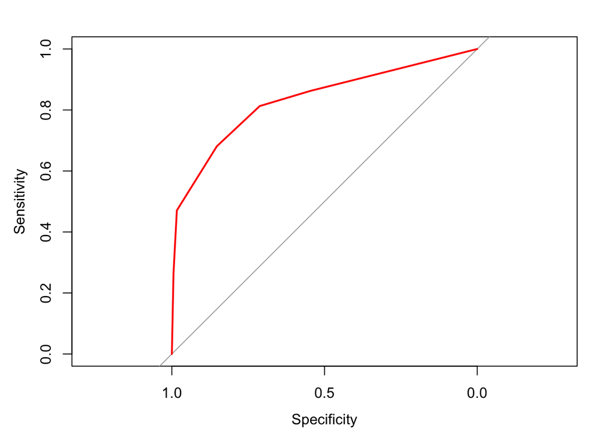

```r
plot(roc,col="red")
```

<!–

*AIC =834.89, AUC = 0.8328 and deviance=826.89.*

–>

6. Build the logistic regression with interation terms and write the logit model. Use the likelihood ratio test to confirm your result.

```r
interlogit <- glm(Survived ~factor(Pclass)+factor(Sex)+factor(Pclass)*factor(Sex), data = titanic, family = "binomial")
summary(interlogit)
```

```
##
## Call:
## glm(formula = Survived ~ factor(Pclass) + factor(Sex) + factor(Pclass) *
##     factor(Sex), family = "binomial", data = titanic)
##
## Deviance Residuals:
##     Min       1Q   Median       3Q      Max
## -2.6248  -0.5853  -0.5395   0.4056   1.9996
##
## Coefficients:
##                                 Estimate Std. Error z value Pr(>|z|)
## (Intercept)                       3.4122     0.5868   5.815 6.06e-09 ***
## factor(Pclass)2                  -0.9555     0.7248  -1.318  0.18737
## factor(Pclass)3                  -3.4122     0.6100  -5.594 2.22e-08 ***
## factor(Sex)male                  -3.9494     0.6161  -6.411 1.45e-10 ***
## factor(Pclass)2:factor(Sex)male  -0.1850     0.7939  -0.233  0.81575
## factor(Pclass)3:factor(Sex)male   2.0958     0.6572   3.189  0.00143 **
## ---
## Signif. codes:  0 '***' 0.001 '**' 0.01 '*' 0.05 '.' 0.1 ' ' 1
##
## (Dispersion parameter for binomial family taken to be 1)
##
##     Null deviance: 1186.7  on 890  degrees of freedom
## Residual deviance:  798.1  on 885  degrees of freedom
## AIC: 810.1
##
## Number of Fisher Scoring iterations: 6
```

```r
mylogit3 <- glm(Survived ~factor(Pclass)+factor(Sex), data = titanic, family = "binomial")
#option 1
anova(mylogit3,interlogit,test="Chisq")
```

|  | Resid. Df | Resid. Dev | Df | Deviance | Pr(>Chi) |
| --- | --- | --- | --- | --- | --- |
| 1 | 887 | 826.8884 | NA | NA | NA |
| 2 | 885 | 798.0969 | 2 | 28.79147 | 5.597724e-07 |

|  | Resid. Df <dbl> | Resid. Dev <dbl> | Df <dbl> | Deviance <dbl> | Pr(>Chi) <dbl> |
| --- | --- | --- | --- | --- | --- |
| 1 | 887 | 826.8884 | NA | NA | NA |
| 2 | 885 | 798.0969 | 2 | 28.79147 | 5.597724e-07 |

2 rows

```r
#option 2
library(lmtest)
lrtest(interlogit,mylogit3)
```

|  | #Df | LogLik | Df | Chisq | Pr(>Chisq) |
| --- | --- | --- | --- | --- | --- |
| 1 | 6 | -399.0484 | NA | NA | NA |
| 2 | 4 | -413.4442 | -2 | 28.79147 | 5.597724e-07 |

|  | #Df <dbl> | LogLik <dbl> | Df <dbl> | Chisq <dbl> | Pr(>Chisq) <dbl> |
| --- | --- | --- | --- | --- | --- |
| 1 | 6 | -399.0484 | NA | NA | NA |
| 2 | 4 | -413.4442 | -2 | 28.79147 | 5.597724e-07 |

2 rows

<!–

*By using the Wald Chi Square, we found that PCclass:Sex term is significant as p-value=5.598e-07<0.05.*

*The logit model can be written as:* $\hat{logit}=3.412-0.9555Pclass2-3.412Pclass3-3.949Sex-0.185 Pclass2:Sex$+ $+2.095 Pclass3:Sex$

–>

7. Report Deviance, AIC, ROC with AUC (the model fit) from the model in part e) and compare the result with the model in part c).

```r
interlogit <- glm(Survived ~factor(Pclass)+factor(Sex)+factor(Pclass)*factor(Sex), data = titanic, family = "binomial")
summary(interlogit)
```

```
##
## Call:
## glm(formula = Survived ~ factor(Pclass) + factor(Sex) + factor(Pclass) *
##     factor(Sex), family = "binomial", data = titanic)
##
## Deviance Residuals:
##     Min       1Q   Median       3Q      Max
## -2.6248  -0.5853  -0.5395   0.4056   1.9996
##
## Coefficients:
##                                 Estimate Std. Error z value Pr(>|z|)
## (Intercept)                       3.4122     0.5868   5.815 6.06e-09 ***
## factor(Pclass)2                  -0.9555     0.7248  -1.318  0.18737
## factor(Pclass)3                  -3.4122     0.6100  -5.594 2.22e-08 ***
## factor(Sex)male                  -3.9494     0.6161  -6.411 1.45e-10 ***
## factor(Pclass)2:factor(Sex)male  -0.1850     0.7939  -0.233  0.81575
## factor(Pclass)3:factor(Sex)male   2.0958     0.6572   3.189  0.00143 **
## ---
## Signif. codes:  0 '***' 0.001 '**' 0.01 '*' 0.05 '.' 0.1 ' ' 1
##
## (Dispersion parameter for binomial family taken to be 1)
##
##     Null deviance: 1186.7  on 890  degrees of freedom
## Residual deviance:  798.1  on 885  degrees of freedom
## AIC: 810.1
##
## Number of Fisher Scoring iterations: 6
```

```r
library(pROC)
prob1=predict(interlogit,type=c("response"))
roc<-roc(titanic$Survived,prob1);
auc(roc);
```

```
## Area under the curve: 0.8328
```

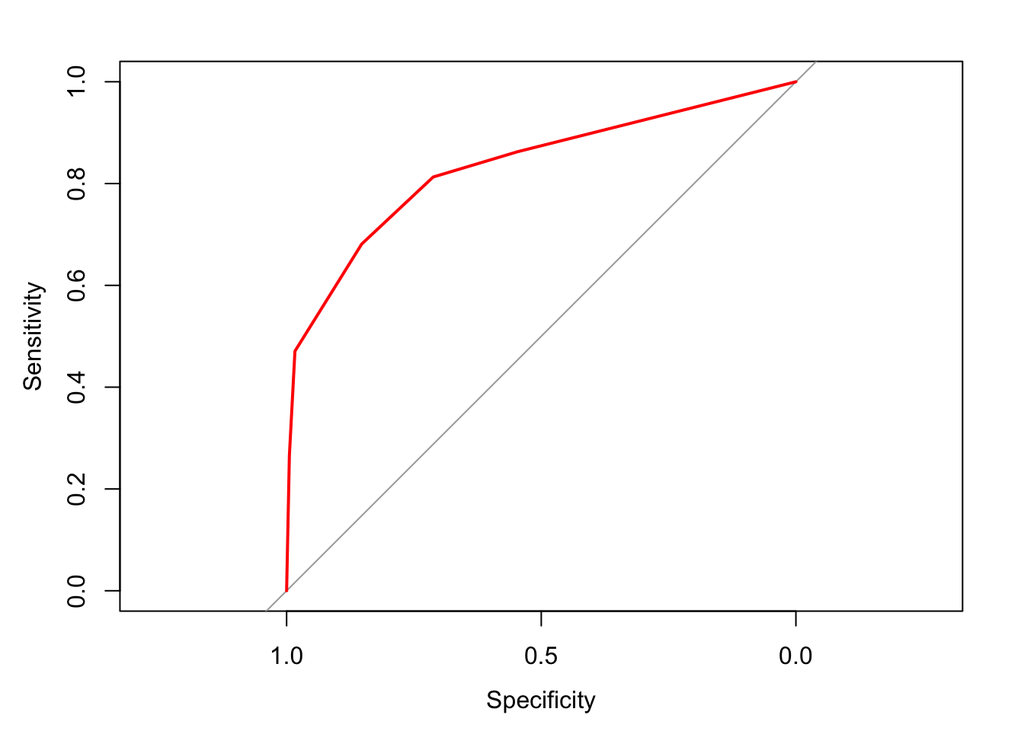

```r
plot(roc,col="red")
```

<!–

*AIC =810.1 with AUC = 0.8328. You can clearly see that Although the AUC from both models are the same, the interaction model provided lower AIC and lower Residual deviance. These results lead us to conclude that the interaction model performs better than the first order model.*

–>

8. From the model in part e), predict the probability of survival for a 35 years old man who got the third class ticket. Show your work by substituting the effect values and use R command to confirm your result. Comment on your result.

```r
newdata=data.frame(Pclass="3",Sex="male");
predict(interlogit,newdata,type="response")
```

```
##         1
## 0.1354467
```

<!–

*Using the predict function as shown above, we obtained 13.54% as the probability of survival*

*By substituting the effect values, we obtain $Prob(Y=1|Sex, Pclass)=\frac{e^{3.412-0.9555(0)-3.412 (1)-3.949 (1)-0.185 (0)(1)+2.095 (1)(1)}}{1+e^{3.412-0.9555(0)-3.412 (1)-3.949 (1)-0.185 (0)+2.095 (1)(1)}}$ =0.1354*

–>

1. From the model in part e), predict the probability of survival for a 20 years old man who got the first class ticket. Show your work by substituting the effect values and use R command to confirm your result. Comment on your result.

```r
newdata=data.frame(Pclass="1",Sex="male");
predict(interlogit,newdata,type="response")
```

```
##         1
## 0.3688525
```

<!–

*Using the predict function as shown above, we obtained 36.88% as the probability of survival*

*By substituting the effect values, we obtain $Prob(Y=1|Sex, Pclass)=\frac{e^{3.412-0.9555(0)-3.412 (0)-3.949 (1)-0.185 (0)(1)+2.095 (0)(1)}}{1+e^{3.412-0.9555(0)-3.412 (0)-3.949 (1)-0.185 (0)+2.095 (0)(0)}}$ =0.3688*

–>